# Ejemplo clustering

###### Seteo directorio

```r
knitr::opts_knit$set(root.dir = "/Users/marinapinkasz/Dropbox/CONICET")
```

###### Librerias

```r
library(dplyr)
library(tidyverse)
library(pheatmap)
library(cluster)
```

```r
rename <- dplyr::rename
select <- dplyr::select
```

#### Acerca de los datos:

Análisis del transcriptoma de la diferenciación de hPSC a neuronas (d0,d6,d10,d17,d30,d50)

Método de análisis:

- Microarray análisis (bulk analysis)
- 3 réplicas por día

###### Importo datos

```r
Db <- readxl::read_xlsx("mmc2.xlsx") %>% select(Gene.Symbol,Day.0.mean,Day.6.mean,Day.10.mean,Day.17.mean,Day.30.mean,Day.50.mean) %>% rename(Gene=Gene.Symbol, Day0= Day.0.mean, Day6 = Day.6.mean, Day10 = Day.10.mean, Day17 = Day.17.mean, Day30= Day.30.mean, Day50 = Day.50.mean) %>% distinct(Gene, .keep_all = TRUE) %>% tibble::column_to_rownames('Gene')
head(Db)
```

|  | Day0 | Day6 | Day10 | Day17 | Day30 | Day50 |
| --- | --- | --- | --- | --- | --- | --- |
| MARCH1 | 3.218347 | 3.365359 | 4.044461 | 4.425925 | 7.018472 | 7.219838 |
| MARC1 | 8.282969 | 8.172334 | 7.694056 | 7.588050 | 6.969187 | 6.848524 |
| MARC2 | 5.386056 | 5.032038 | 4.661524 | 4.684576 | 4.596605 | 5.489428 |
| MARCH2 | 6.542848 | 6.415780 | 5.857067 | 5.968753 | 6.603533 | 6.563498 |
| MARCH3 | 6.116864 | 5.757929 | 5.046626 | 5.212989 | 5.001813 | 5.695218 |
| MARCH4 | 5.476369 | 5.617798 | 5.611392 | 6.046026 | 7.143989 | 7.686468 |

Voy a achicar la tabla para que los tiempos sean más cortos (sample_n es una funcón que aleatoriamente elige la cantidad de datos que vos le decis)

```r
set.seed(132)
Db %>%sample_n(500) -> db
head(db)
```

|  | Day0 | Day6 | Day10 | Day17 | Day30 | Day50 |
| --- | --- | --- | --- | --- | --- | --- |
| MEN1 | 7.773899 | 8.100578 | 7.269669 | 7.602597 | 7.607434 | 7.749002 |
| TIGD1 | 6.567754 | 6.778794 | 6.432879 | 7.000845 | 8.287785 | 8.696387 |
| THNSL2 | 4.923762 | 4.925929 | 4.960137 | 4.555246 | 4.351174 | 4.240266 |
| GPN1 | 9.880026 | 9.957188 | 9.604294 | 9.442664 | 8.724978 | 8.574036 |
| RAB40B | 5.754513 | 6.021789 | 6.380422 | 6.326225 | 5.784722 | 5.857734 |
| RPS6 | 13.566394 | 13.620864 | 13.447660 | 13.393673 | 13.385488 | 12.818350 |

### Escalado de los datos

Si los valores de expresión de un gen están en una escala mucho más alta que los otros genes, ese gen afectará la distancia más que otros. Si ese es el caso, podemos escalar las variables. La forma tradicional de escalar variables es restar su media y dividir por su desvio estándar, esta operación también se llama “estandarización”. Si esto se hace en todos los genes, cada gen tendrá el mismo efecto en las medidas de distancia (la función scale() hace esto)

En este caso, escalo para que la suma de las medias de expresión para cada gen en los 6 días sea 0.

```r
rnames <- rownames(db)
cnames <- factor(c("Day0", "Day6", "Day10", "Day17", "Day30", "Day50"),ordered = TRUE)
db %>% apply(1, scale) %>% `rownames<-`(cnames) %>% `colnames<-`(rnames) -> mat
mat[,1:10]
```

```
##             MEN1      TIGD1     THNSL2       GPN1       RAB40B        RPS6
## Day0   0.3309772 -0.7593368  0.8253529  0.8814646 -0.971615271  0.67644063
## Day6   1.5318677 -0.5387034  0.8321186  1.0132369  0.003237621  0.86605207
## Day10 -1.5226017 -0.9003435  0.9389259  0.4105895  1.311308203  0.26312368
## Day17 -0.2987389 -0.3065592 -0.3252562  0.1345682  1.113632494  0.07519520
## Day30 -0.2809573  1.0388830 -0.9624280 -1.0910449 -0.861433306  0.04670298
## Day50  0.2394529  1.4660598 -1.3087132 -1.3488142 -0.595129741 -1.92751455
##             GPR56       RTCB    LAMTOR3     UGT1A1
## Day0  -1.52977718  0.6914543 -1.4115196  0.4486662
## Day6  -0.84246799  0.9692811 -0.5081066  0.6682305
## Day10  0.05889196  0.6409557 -0.4896566  0.8226180
## Day17  0.47316313  0.1655775  0.2140724  0.2425990
## Day30  1.04160244 -1.0095382  1.2624915 -0.3049903
## Day50  0.79858764 -1.4577303  0.9327189 -1.8771236
```

### Exploración de los datos

Heatmap para ver cómo se ven los datos

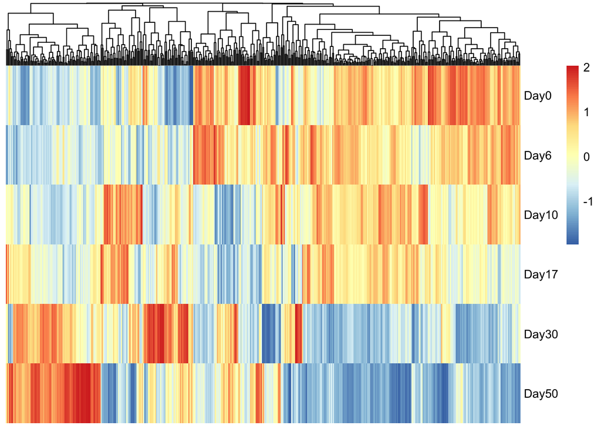

```r
pheatmap(mat,
         show_rownames= T,
         show_colnames= F,
         cluster_rows = FALSE)
```

- Hay genes que parece que a medida que avanza la diferenciación bajan su expresión y otros que aumentan su expresión
- Los días 0-6, 10-17, 30-50 no parecen variar mucho en su perfil de expresión.
- Parece que los días 0,6,10 y 17 se parecen más en su perfil de expresión.

### PCA: Reducción dimensional

Las técnicas de reducción de dimensiones son un conjunto de procesos para reducir el número de variables aleatorias obteniendo un conjunto de variables principales. Por ejemplo, en el contexto de una matriz de expresión génica en diferentes días de diferenciación, esto podría significar obtener un conjunto de nuevas variables que cubran la variación en conjuntos de genes. De esta manera, los días se pueden representar mediante un par de variables principales en lugar de miles de genes.

```r
set.seed(235)
pca <- prcomp(mat)
pca$x
```

```
##              PC1        PC2        PC3         PC4        PC5           PC6
## Day0  -15.703004  11.498783  -1.061943   7.9077637 -0.6452128  3.775626e-15
## Day6  -12.446782   6.411985  -2.069364 -10.0131933  2.1877346  3.834932e-15
## Day10  -9.423370 -10.616470   3.755534  -0.8309566 -8.0456269 -3.457521e-16
## Day17  -3.972722 -11.666358   2.604590   2.6571354  7.9329233 -1.304100e-14
## Day30  17.957058  -1.926957 -14.110760   0.7667116 -1.1585322  6.246739e-15
## Day50  23.588819   6.299017  10.881944  -0.4874608 -0.2712859  9.527969e-16
```

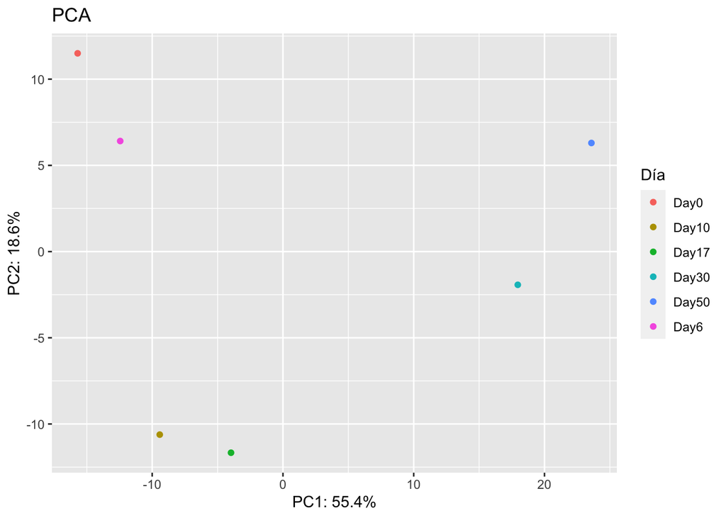

```r
set.seed(234)
var_explained <- pca$sdev^2/sum(pca$sdev^2)

pca$x %>% as.data.frame() %>%  ggplot(aes(x=PC1,y=PC2)) + geom_point(aes(colour=rownames(pca$x))) + labs(title= "PCA",color = "Día", x=paste0("PC1: ",round(var_explained[1]*100,1),"%"),
       y=paste0("PC2: ",round(var_explained[2]*100,1),"%"))
```

- El componente 1 me explica un 55,4% de la variación en la expresión de genes entre los días
- El componente 2 me explica un 18,6% de la variación en la expresión de genes entre los días
- Vemos que efectivamente los días 0-6, 10-17, 30-50 se parecen más en su expresión de genes.

### Clustering

Cómo nuestras muestras se relacionan entre sí. ¿Nuestras réplicas son similares entre sí? ¿Las muestras del mismo grupo de tratamiento tienen un perfil de expresión similar? ¿Los pacientes con enfermedades similares tienen perfiles de expresión génica similares? ¿Las líneas celulares que tengo, son similares en cuanto a su expresión génica?

Quiero ver qué tanto se parecen los días en su perfil de expresión de los genes. ¿Hay días que tengan similar perfil de expresión génica?. ¿A medida que avanza la diferenciación, se expresan igual los genes?

Necesitamos definir una métrica de distancia o similitud entre los perfiles de expresión de los días y usar esa métrica para ver si hay grupos de días que sean más similares entre sí que el resto.

Hay varios métodos para calcular las distancias

- Distancia euclediana: Es la que en general se usa para hacer clusterings. Es la suma de distancias al cuadrado y toma la raíz cuadrada del valor resultante. Es más suceptible a outliers.

Otros métodos: Manhattan distance; correlation distance

```r
dist <-  dist(mat,method="euclidean")
dist
```

```
##           Day0     Day6    Day10    Day17    Day30
## Day6  19.14888
## Day10 26.13154 22.84894
## Day17 28.08594 24.77956 17.30946
## Day30 39.17627 35.58554 34.55987 30.68228
## Day50 42.23933 39.53606 38.56530 35.04433 26.95142
```

##### K-MEANS

Este método divide o divide los puntos de datos, en nuestro ejemplo los días (pueden ser pacientes, líneas celulares etc.), en un número “k” predeterminado de grupos. El algoritmo se inicializa con una selección aleatoria de k “centroides”. Sería un día hipotético con valores de expresión génica. Pero en la fase de inicialización, esos valores de expresión génica se eligen al azar dentro de los límites de las distribuciones de expresión génica de los días. Luego a cada día se le asigna el centroide más cercano y, en la siguiente iteración, los centroides se establecen en la media de los valores de los genes en el grupo. Este proceso de establecer centroides y asignar días a los grupos se repite hasta que se minimiza la suma de las distancias cuadradas a los centroides del grupo.

En principio como vimos en el PCA y por el HEATMAP me fijo con un k=3

```r
set.seed(101)

kclu=kmeans(mat,centers=3)


table(kclu$cluster)
```

```
##
## 1 2 3
## 2 2 2
```

```r
daykclu = data.frame(
                    Day =rownames(mat),
                    cluster=kclu$cluster)

table(daykclu)
```

```
##        cluster
## Day     1 2 3
##   Day0  1 0 0
##   Day10 0 0 1
##   Day17 0 0 1
##   Day30 0 1 0
##   Day50 0 1 0
##   Day6  1 0 0
```

Clusteriza de la misma forma que veníamos viendo

Multi-dimensional scaling: Muestra los datos de distancia de un espacio de alta dimensión en un espacio de menor dimensión sin mucha pérdida de información. El objetivo general de MDS es representar fielmente estas distancias con las dimensiones lo más bajas posibles (otro método de reducción de dimensionalidad)

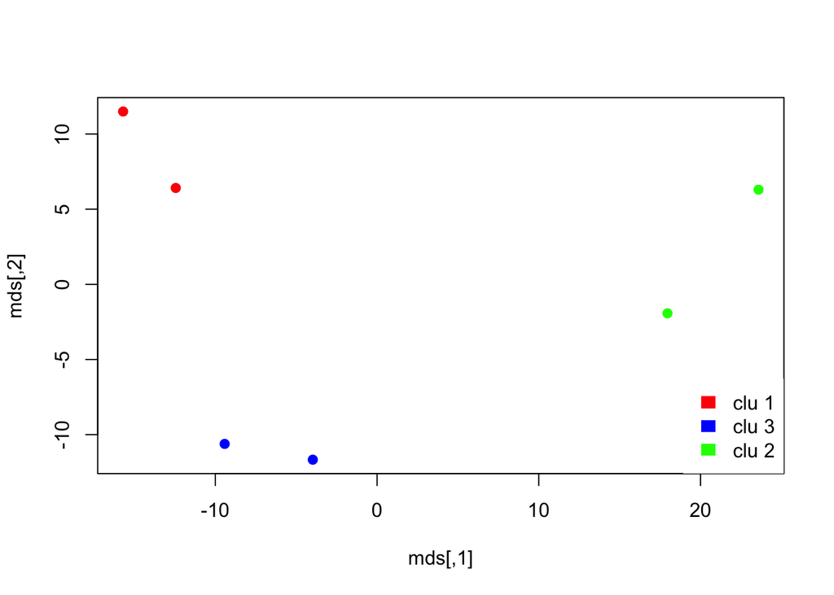

```r
# Calcular las distancias
dists=dist(mat)

# calculate “Multi-dimensional scaling”
mds=cmdscale(dists)

# grafico de los días en el espacio
plot(mds,pch=19,col=rainbow(3)[kclu$cluster])

# leyendas para los clusters
legend("bottomright",
       legend=paste("clu",unique(kclu$cluster)),
       fill=rainbow(3)[unique(kclu$cluster)],
       border=NA,box.col=NA)
```

¿Para qué nos puede servir esta información?

- Para saber qué tanto se parecen los días entre sí
- Si tengo que hacer un experimento, puedo priorizar sacar muestras al día 6, 17 y 50.
- Me puede interesar saber qué genes son los que hacen que se vean estas diferencias en los grupos de genes (análisis de expresión diferencial)

##### Elegir el k

Hay varios métodos para calcular el k óptimo. Los más comunes son:

- Silhouette
- Elbow plot
- Gap statistic

Elbow plot: Mide la variación intra-cluster, que queremos que sea lo más chica posible.

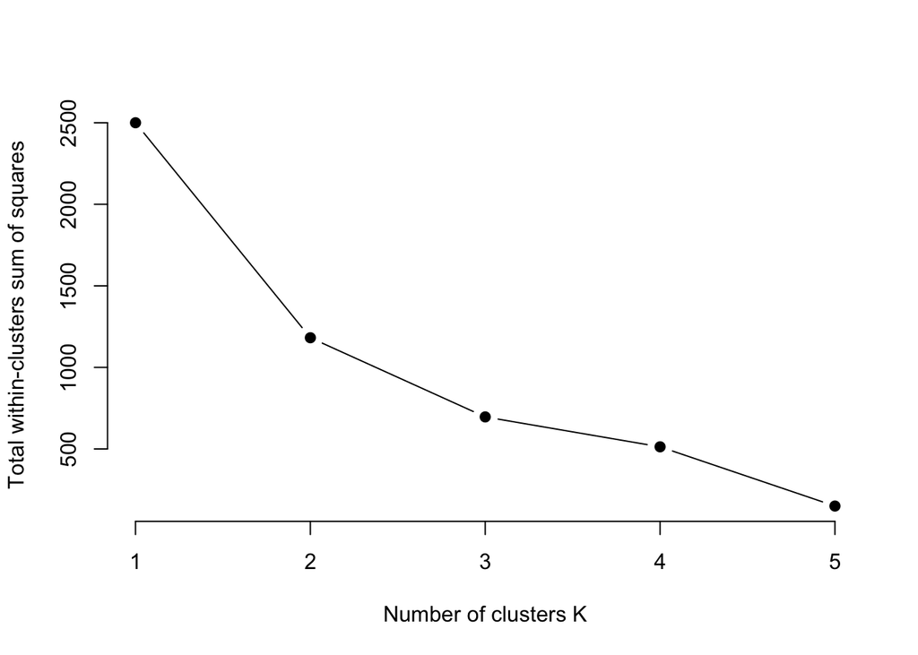

```r
set.seed(123)

#  función para calcular la suma total de cuadrados dentro del clúster
wss <- function(k) {
  kmeans(mat, k, nstart = 10 )$tot.withinss
}

# k de 1 a 5 (n-1)
k.values <- 1:5

# extraer wss for 2-5 clusters
wss_values <- map_dbl(k.values, wss)

plot(k.values, wss_values,
       type="b", pch = 19, frame = FALSE,
       xlab="Number of clusters K",
       ylab="Total within-clusters sum of squares")
```

k=2

```r
set.seed(102)


kclu=kmeans(mat,centers=2)


table(kclu$cluster)
```

```
##
## 1 2
## 2 4
```

```r
daykclu = data.frame(
                    Day =rownames(mat),
                    cluster=kclu$cluster)

table(daykclu)
```

```
##        cluster
## Day     1 2
##   Day0  0 1
##   Day10 0 1
##   Day17 0 1
##   Day30 1 0
##   Day50 1 0
##   Day6  0 1
```

Ahora los tiempos 0,6,10 y 17 clusterizan juntos.

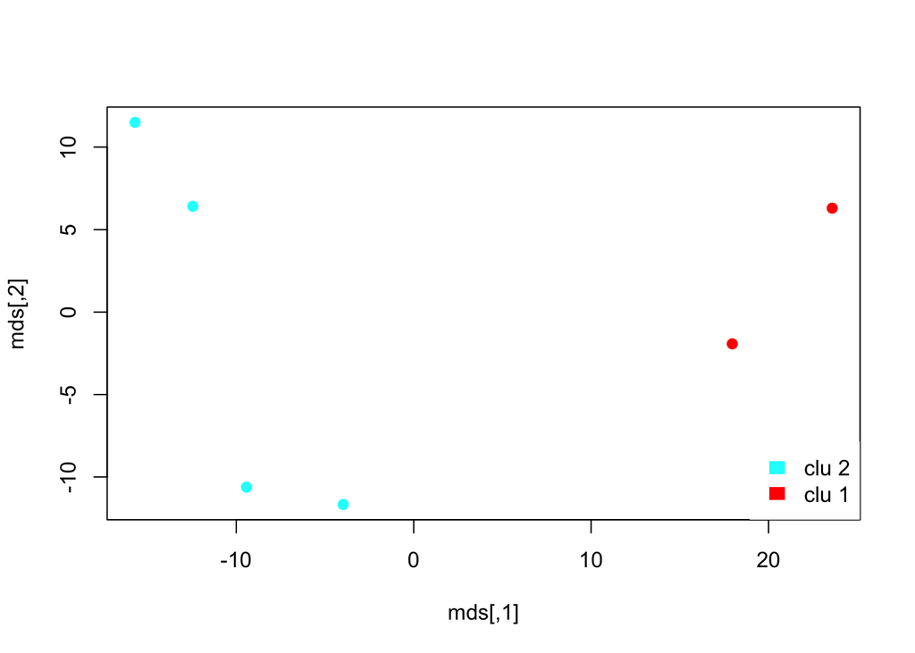

```r
dists=dist(mat)


mds=cmdscale(dists)


plot(mds,pch=19,col=rainbow(2)[kclu$cluster])


legend("bottomright",
       legend=paste("clu",unique(kclu$cluster)),
       fill=rainbow(2)[unique(kclu$cluster)],
       border=NA,box.col=NA)
```

Días 0,6,10 y 17 se parecen más entre ellos y por otro lado están los días 30 y 50

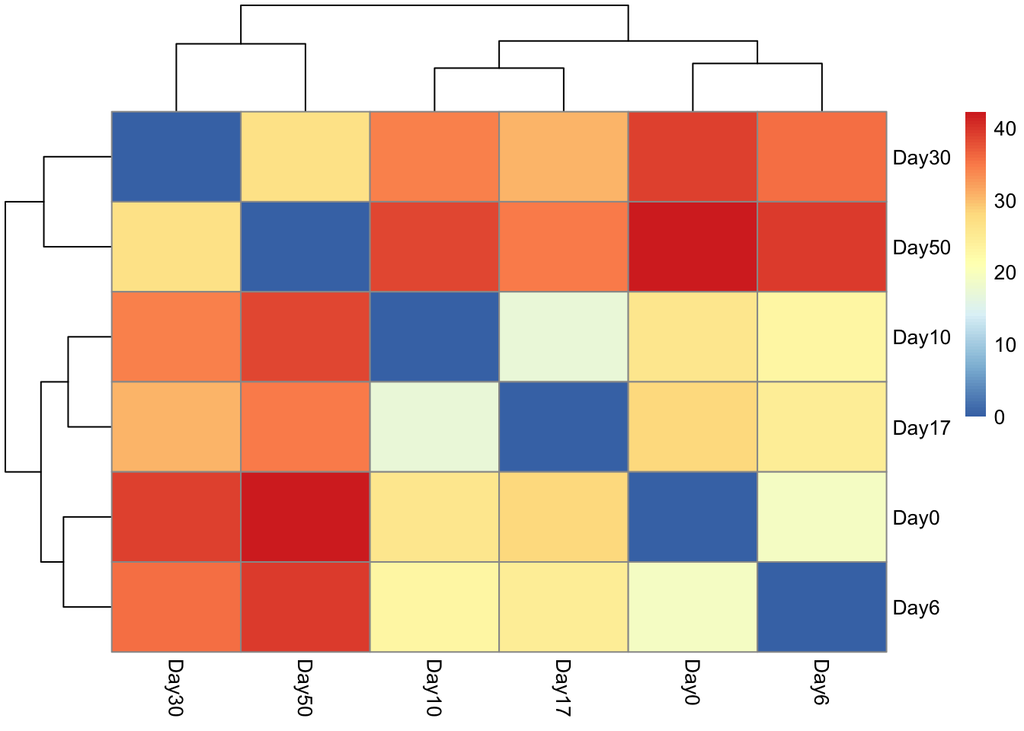

```r
pheatmap(data.matrix(dist(mat)),
         clustering_distance_rows = dist(mat),
         clustering_distance_cols = dist(mat))
```

Efectivamente parecen verse dos clusters. Hay menos distancia entre los dias 0,6,17 y 10.

¿A qué puede deberse?

- Al día 17 la mayoría de las células continuan siendo progenitoras neuronales mientras que al día 30 ya son neuronas inmaduras que aún carecen de propiedades funcionales.

#### Hiearchical clustering

Ver la relación de los puntos de datos individuales y las relaciones de los clústeres. Esto se logra uniendo sucesivamente pequeños grupos entre sí en función de la distancia entre grupos. Finalmente, obtiene una estructura de árbol o un dendrograma que muestra la relación entre los puntos de datos individuales y los grupos. La altura del dendrograma es la distancia entre grupos.

El argumento del método define los criterios que dirigen cómo se fusionan los subgrupos. Durante la agrupación, comenzando con grupos de un solo miembro, los grupos se fusionan en función de la distancia entre ellos. Hay muchas formas diferentes de definir la distancia entre grupos y, según la definición que utilice, los resultados de la agrupación jerárquica cambian.

método complete: la distancia entre dos grupos se define como la mayor distancia entre los miembros de los dos grupos.

otros métodos (?hclust) : “ward.D”, “ward.D2”, “single”, “average”

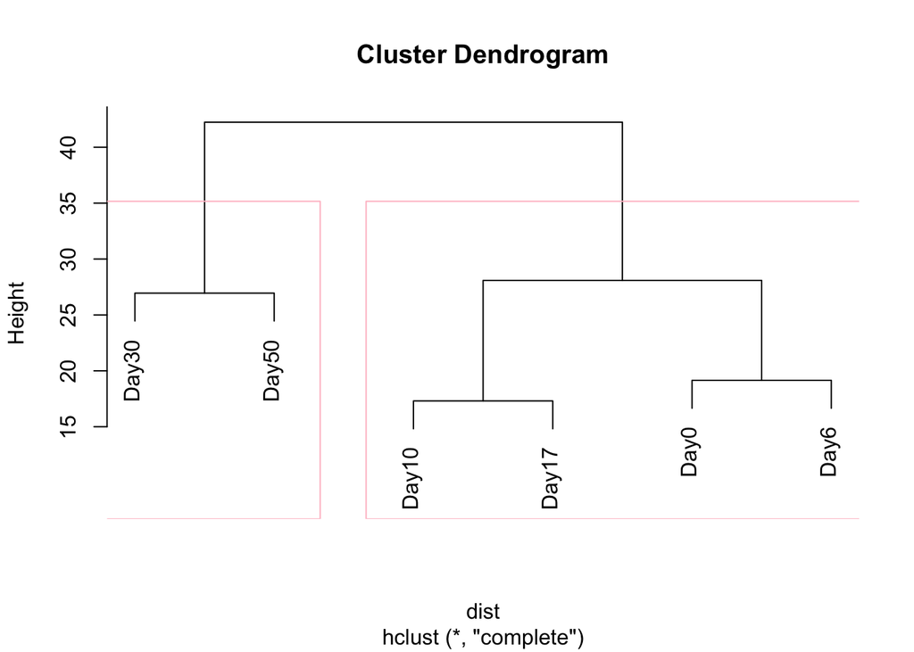

```r
hcl=hclust(dist,method="complete")
plot(hcl)
rect.hclust(hcl, h = 30, border = "pink")
```

Si cambio el método para calcular las distancias, puede encontrar distintos clusters:

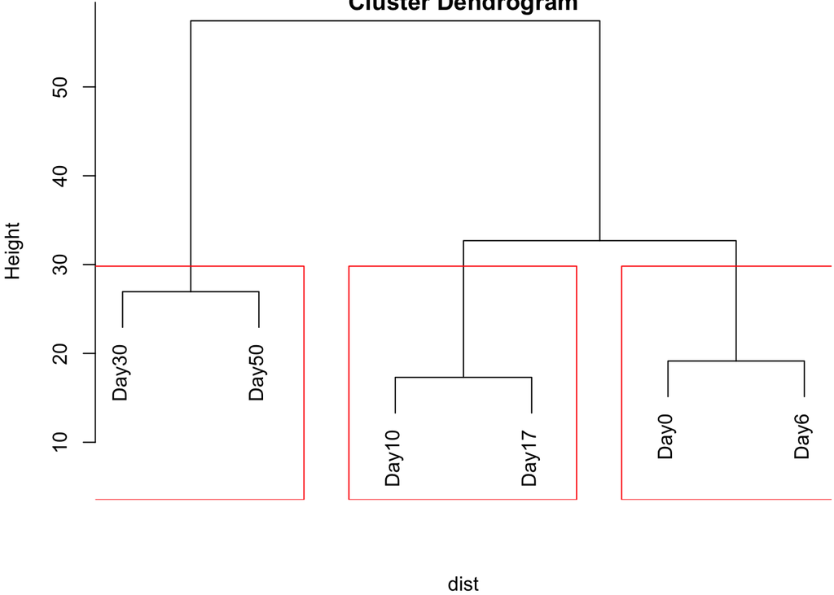

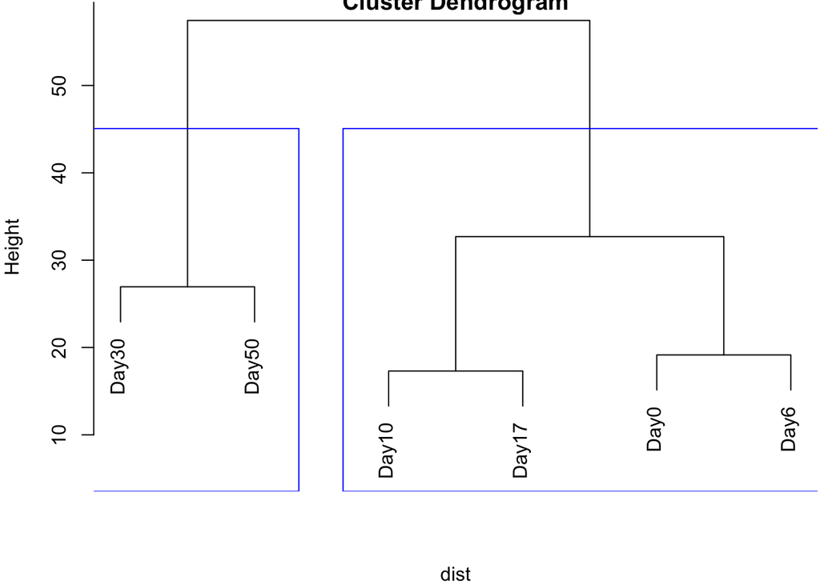

```r
par(mar = c(4, 4, .1, .1))

hc=hclust(dist,method="ward.D")
plot(hc)
rect.hclust(hc, h = 30, border = "red")

plot(hc)
rect.hclust(hc, h = 35, border = "blue")
```

Devuelta vemos que se forman dos grandes clusters o podemos generar 3 clusters.

¿Cómo obtenemos los clusters?

Podemos generar la cantidad deseada de grupos o grupos obtenidos al cortar el dendrograma a una cierta altura (por ejemplo según donde queramos cortar se van a formar dos o tres clusters)

```r
clu.k3=cutree(hc,k=3) #cortar el árbol para que haya 3 clusters

clu.h40=cutree(hc,h=40) # cortar el árbol a la altura 40
table(clu.k3) # número de muestras por clusters
```

```
## clu.k3
## 1 2 3
## 2 2 2
```

```r
table(clu.h40) ## número de muestras por clusters
```

```
## clu.h40
## 1 2
## 4 2
```

También podemos usar los métodos anteriores para elegir el k óptimo…

```r
annotation_col = data.frame(
                    Cluster3 =as.factor(clu.k3),
                    Cluster2= as.factor(clu.h40),
                    Day= rownames(mat))
rownames(annotation_col)=rownames(mat)
```

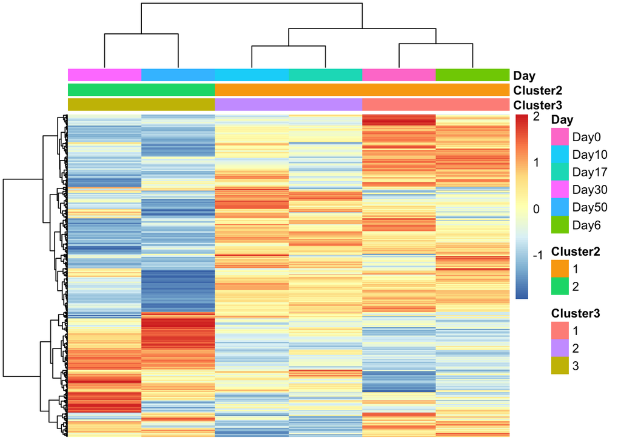

```r
pheatmap(t(mat),show_rownames=FALSE,show_colnames=FALSE,
         annotation_col=annotation_col,
         scale = "none",clustering_method="ward.D2",
         clustering_distance_cols="euclidean")
```

### Referencias

- Libro: https://compgenomr.github.io/book/
- Paper: Floruta et al. 2017: https://www.cell.com/stem-cell-reports/comments/S2213-6711(17)30430-7